# CS:GO Roundtime analysis

## Idea of the analysis

The idea of this analysis is to study in depth the differences between the play styles of CS regions by using solely statistical methods. Not a single demo has been watched in order to make this analysis.

The main variable focused on is the **length of the rounds won**. The idea is to see what kind of rounds the teams are winning on either side. Of course, as there are always to teams in the game, the data set would be biased if I used regional data (such as Esea pro league’s regular season). Due to this reason only data from recent *major tournaments* is used. For those not aware, these *“Major tournaments”* are big tournaments that are sponsored by the game makers and have teams from all around the world.

## Data

Data is from **major tournaments** for previously mentioned reasons. The data is originally scarepd from the HLTV.org with https://github.com/ReagentX/HLTV-Scraper (credit to ReagentX). The data consist of 7949 rounds of data out of which 4926 were rounds won by EU teams and 1667, 746 and 610 won by CIS (CIS-Region in CS:GO context), NA and SA teams respectively.

```
##      Team           Round_duration_in_seconds    Winner
##  Length:7949        Min.   : 35.70            Length:7949
##  Class :character   1st Qu.: 84.41            Class :character
##  Mode  :character   Median :107.14            Mode  :character
##                     Mean   :105.19
##                     3rd Qu.:127.45
##                     Max.   :154.98
##
##      Type                                    Major
##  Length:7949        Eleague 2017                :2232
##  Class :character    PGL Krakow 2017            :1119
##  Mode  :character   ESL One Cologne 2016        : 808
##                     Dreamhack Open 2015         : 676
##                     MLG Columbus 2016           : 629
##                     Eleague Major Qualifier 2017: 469
##                     (Other)                     :2016
```

|  | Team | Round_duration_in_seconds | Winner | Type | Major |
| --- | --- | --- | --- | --- | --- |
| 27 | SA | 108.307891845703 | CT | Normal | Eleague Major Qualifier 2017 |
| 28 | SA | 112.278778076172 | CT | Normal | Eleague Major Qualifier 2017 |
| 29 | SA | 55.0606689453125 | CT | Eco | Eleague Major Qualifier 2017 |
| 30 | SA | 78.6358032226563 | CT | Normal | Eleague Major Qualifier 2017 |
| 33 | SA | 111.465881347656 | CT | Normal | Eleague Major Qualifier 2017 |
| 34 | SA | 77.68994140625 | CT | Eco | Eleague Major Qualifier 2017 |
| 35 | SA | 99.177978515625 | CT | Normal | Eleague Major Qualifier 2017 |
| 36 | SA | 129.4990234375 | CT | Force buy | Eleague Major Qualifier 2017 |
| 37 | SA | 111.895751953125 | CT | Force buy | Eleague Major Qualifier 2017 |
| 46 | SA | 124.621337890625 | T | Normal | Eleague Major Qualifier 2017 |

[output cut: 7939 more lines]

## Gunrounds won as Terrorist

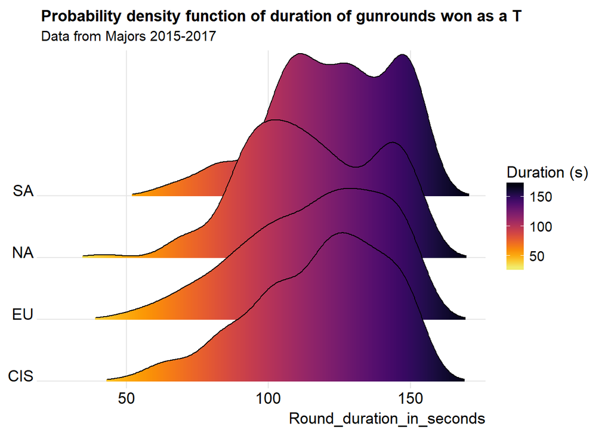

*Terrorist are the team that attack and largely dictate the speed of the round* but don’t solely decide when the round ends.

The length of gunrounds won by SA and NA team as a function is quite different from those of won by EU and CIS teams. It seems that both of them have a **less predictable execution time** and their wins can be fast- or slow-paced. **I.e. the variance of round time is larger.** To me, this seems to be a stylistic difference between regions and it makes sense because EU and CIS teams often practice with each other and so do NA and SA. This also could come from the more “free” style of playing and chasing for fast round finish (overconfident and overzealous playing).

I must mention that higher sample size might be the reason why EU and CIS teams have a more normally distributed density function when the round win happens. I doubt it explains the lower variance.

## Gunrounds won as Counter-Terrorist

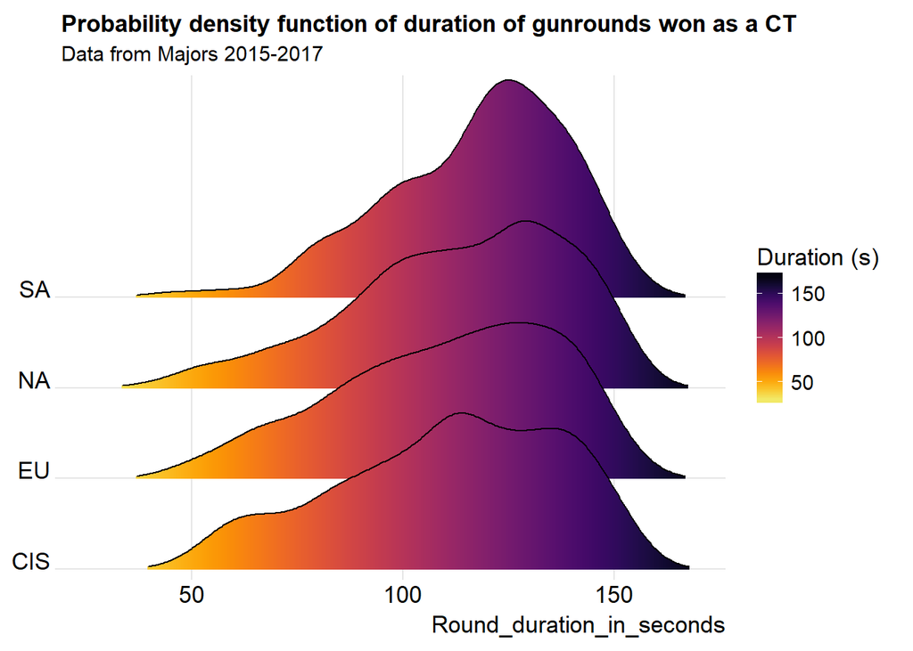

*Counter-terrorist rarely dictate the speed of the round* but a team can choose to be the aggressor by doing controllable counter-attack towards terrorist. In case of rounds won, the rounds can only be quick if the whole counter-terrorist team elimates all terrorists.

The length of gunrounds won as a counter-terrorist shows that CIS-teams win considerable amount of fast rounds. This can be either overzealous plays or controlled aggressing by the CIS-teams. Most interestingly **it seems that SA teams are more likely than others to stretch the rounds** to be long. This can be **a result of composure** to not rush things.

Variances of the samples are actually quite similar. This would suggest that the variance difference in the first chart is more than likely caused by actual game play differences rather than just smaller sample size.

*-Markus Keski-Säntti*